# COVID-19 Concern and Citizen Trust in Different Institutions

Vivian Nguyen

2021-12-16

## Overview

Note: I wrote this paper for Government 1372: Political Psychology, a data science in the Harvard Government department. At this point, I was gaining proficiency in R, but had not developed a sophisticated understanding of statistics and causal inference yet. That said, this paper was one of my first large data science projects, and was driven by my newfound passion for applying data science techniques and programming experience to (what I deem to be) relevant real-world problems. In Fall 2021, the pandemic was still a large public health concern, but the public was battling a mixture of fear and desire for a return to normalcy. I was very interested in what sources people trusted to provide them information about the pandemic, and how that related to their COVID anxieties – additionally, how does partisan alignment interact with these variables?

## Abstract

Over the past two years, the coronavirus (COVID-19) pandemic has disrupted the lives of billions of people, and has taken the lives of millions. In that time, American citizens have reported notable levels of concern about the pandemic (Albertson & Gadarian, 2020). Trust in government and officials is important in times of crisis, so how does the new spike in anxiety relate to trust? This paper analyzes the correlative relationship between concern about the pandemic and the trust that Americans have in their government and other important institutions. After observing 48 weeks of panel data of N ≈ 1,000 from the KnowledgePanel, it is revealed that there is a positive correlation between coronavirus concern and trust in state and federal government, as well as the CDC and national health officials. Additionally, it is shown that there exists a non-negligible factor of partisan identity in the determination of trust in these important information sources – an indicator of the pandemic’s unique politicization.

## Trust in Various Institutions

Not only do attitudes about COVID-19 policy and changes in trust have important consequences for the success of public health initiatives and planning, but they also may have an impact on electoral politics. Increased citizen trust in government and health advisory could contribute to previously studied “rally-round-the-flag” effects, where politicians gain popular support during times of national hardship (Mueller, 1970). Decreased trust in, perhaps paired with dissatisfaction with, government officials and their pandemic policies could sway election results against incumbents who are usually at an advantage otherwise – a working paper by Noland and Zhang (2021) reports that if Donald Trump handled the pandemic about 20 percent better, or had the pandemic not happened at all, American citizen faith would not have decreased to a level that allowed Joseph Biden to win the 2020 election and claim the presidency.

## Trust as an Outcome

Existing literature about trust in government, social trust, and the effects of trust has highlighted the importance of trust in times of crisis. In these works, trust in different institutions for important information about relevant events has been treated as an independent variable to assess outcomes such as compliance with public health safety mandates, personal increased pandemic- hygiene behaviors, and impacts on electoral politics. However, there exists much less work on what influences citizen trust.

One such work comes from a 2010 study by Albertson and Gadarian, who manipulated respondent anxiety to see its effects on trust as an outcome variable. The researchers hypothesized that anxiety can increase or decrease citizen trust in different experts, but more specifically, a threat from an external place, far from the government’s jurisdiction, including pandemics, was predicted to lead to increased anxiety that lended itself to increased trust in governmental actors. As outlined in their report on the study, this hypothesis was supported by system justification theory (Jost, 2020), which posits that people cope with negative events by throwing their support behind and faith in existing systems, such as the government and institutions that are widely recognized. At a basic level, this is reasonable, as it is expected that anxious people would look to trusted officials for information in times of crisis and uncertainty.

After establishing this theoretical framework, the researchers tested their hypothesis by comparing participants’ trust in different experts (Centers for Disease Control and Prevention, U.S. President, friends in the medical field, and more) between the control group and the treatment group, where respondents were treated with H1N1 (“swine flu”; influenza A virus pandemic in 2009 and 2010) anxiety. Trust in various experts to provide information about the H1N1 pandemic was reported on scales ranging from “not at all” to “a great deal.” For most of the experts the study asked respondents about, the treatment group reported more trust than did the control group. This effect was clear for respected “expert” federal health organizations – anxiety about the H1N1 virus led respondents to trust the Centers for Disease Control and Prevention (CDC) and the U.S. Department of Health and Human Services more to provide information about H1N1. Interestingly, the treatment did not cause significant increases in trust in public government officials like Barack Obama, perhaps because he was not perceived to have relevant expertise on the public health crisis despite speaking about it multiple times.  
A decade ago, it was intuitive that anxiety about a public health crisis would lead Americans to trust in federal health agencies to provide relevant information about the pandemic more. But as Albertson and Gadarian have aptly pointed out in their 2020 Washington Post analysis of the coronavirus in the United States, COVID-19 is different from H1N1 in that it is heavily politicized and treated as a partisan issue. With partisan divides underpinning Americans’ emotional response to pandemic policies, the pandemic’s effects on anxiety and trust are no longer clear nor intuitive. Do COVID-anxious people place their trust in health experts? Does partisanship shape respondent trust in institutions and experts more than actual anxiety?

In this research paper, I aim to analyze the correlative relationship between anxious concern about COVID-19 and trust in different institutions (the CDC, national health advisors, the federal government, and the state government). I also compare this relationship to the relationship between partisanship and the different trust responses to determine if politicization of the pandemic has gone so far as to make party identification more important than concern about the virus in deciding citizens’ trust in important pandemic policymaking institutions.

## Hypotheses

$H_1$ : Concern about COVID-19 is positively correlated with trust in all four bodies (CDC, national health advisors, federal government, and state government).

$H_2$ : Partisan identification (Democrat or Republican) has at least as much predictive power as COVID-19 concern in determining respondent trust in the COVID-19 information sources.

$H_{2.1}$ : Respondents who identify as Democrats are more likely to trust the CDC for pandemic information than those who identify as Republicans.

## The Axios/Ipsos Coronavirus Index

To test these hypotheses, Lucy and I used data from the Axios/Ipsos Coronavirus Index, a weekly survey fielded from the Ipsos KnowledgePanel. The Ipsos KnowledgePanel is a longstanding online panel of about 60,000 United States members from diverse populations, including racial minorities, veterans, people with disabilities, adolescents, LGBTQ+ people, gun owners/ households, and more. Specifically, (we) analyzed the data from respondents surveyed from March 13, 2020 to June 28, 2021 from Axios/Ipsos Poll Waves 1 through Wave 48, which had weekly sample sizes of about 1,000 adults.

Each week, the poll collected responses about Americans’ behaviors, risk perceptions, attitudes about COVID-19. A few questions were of interest to me, regarding (1) COVID-19 concern, (2) trust in the federal government, (3) trust in the state government, (4) trust in the CDC, (5) and trust in national public health officials. These questions were asked as follows:

1.) “How concerned are you, if at all, about the coronavirus or COVID-19 outbreak?”

(a.) Extremely concerned

(b.) Very concerned

(c.) Somewhat concerned

(d.) Not very concerned

(e.) Not at all concerned

2.) “How much trust do you have in [the federal government] to provide you with accurate information about coronavirus or COVID-19?”

(a.) A great deal

(b.) A fair amount

(c.) Not very much

(d.) None at all

3.) “How much trust do you have in [your state government] to provide you with accurate information about coronavirus or COVID-19?”

[Same answer options as above]

4.) “How much trust do you have in [the Centers for Disease Control, or CDC] to provide you with accurate information about coronavirus or COVID-19?”

[Same answer options as above]

5.) “How much trust do you have in [national public health officials] to provide you with accurate information about coronavirus or COVID-19?”

[Same answer options as above]

We also used the responses to demographic questions as control variables, including respondent age, education level, gender, income, and party identification.

We recoded the COVID concern, trust, and some control variables to make them more readable, where higher values corresponded with higher concern, trust, age, etc. For the party variable, a value of 0 corresponded with Democrats, 1 with Independents, and 2 with Republicans.

## Methods

To test $H_1$ , “Concern about COVID-19 is positively correlated with trust in all four bodies (CDC, national health advisors, federal government, and state government),” I ran four linear regression models, each with one of the four trust variables as the outcome variable and dependent variables such as COVID-19 concern, age, education, ethnicity, gender, and party. To show the regression results, I plotted the regression coefficients of each dependent variable for each trust outcome variable. This analytical method and plot combination was chosen for this hypothesis because the linear regression modelling reveals a presence, or lack of, positive correlative relationship between each trust outcome variable and explanatory variables such as COVID concern. The coefficient plot visually demonstrates the relationships between each predictor variable and respondents’ trust, including the effect of COVID concern on trust.

To test $H_2$, “Partisan identification has at least as much predictive power as COVID-19 concern in determining respondent trust in the COVID-19 information sources,” I again ran the four linear regression models. In order to compare the ability of party identification versus COVID concern to explain the variance in trust in different institutions and actors, I used the `scale()` function to standardize the previously different scales of the explanatory variables. This method is appropriate to test $H_2$ because it allows direct comparison of the regression coefficients associated with COVID concern and party identification. Thus, the variable tied to the larger scaled coefficient can be interpreted as the dependent variable with more predictive power for trust in coronavirus information sources.

To test $H_{2.1}$ , “Respondents who identify as Democrats are more likely to trust the CDC than those who identify as Republicans,” I plotted the predicted trust in the CDC for Democrats versus the predicted CDC trust for Republicans using the `predict()` function. This analytical methodology was chosen because it reveals respondents’ predicted trust in the CDC by party.

## Results

For all trust outcomes (trust in the federal government, trust in state governments, trust in the CDC, and trust in national health officials), changes in COVID concern, education, and party were found to have statistically significant effects on trust. The plots below show the regression coefficients of each predictor variable for the trust outcome variables, with 95% confidence intervals around each coefficient estimate.

The control variables of gender, ethnicity, and age had near-zero coefficients in each model. Figure 1:

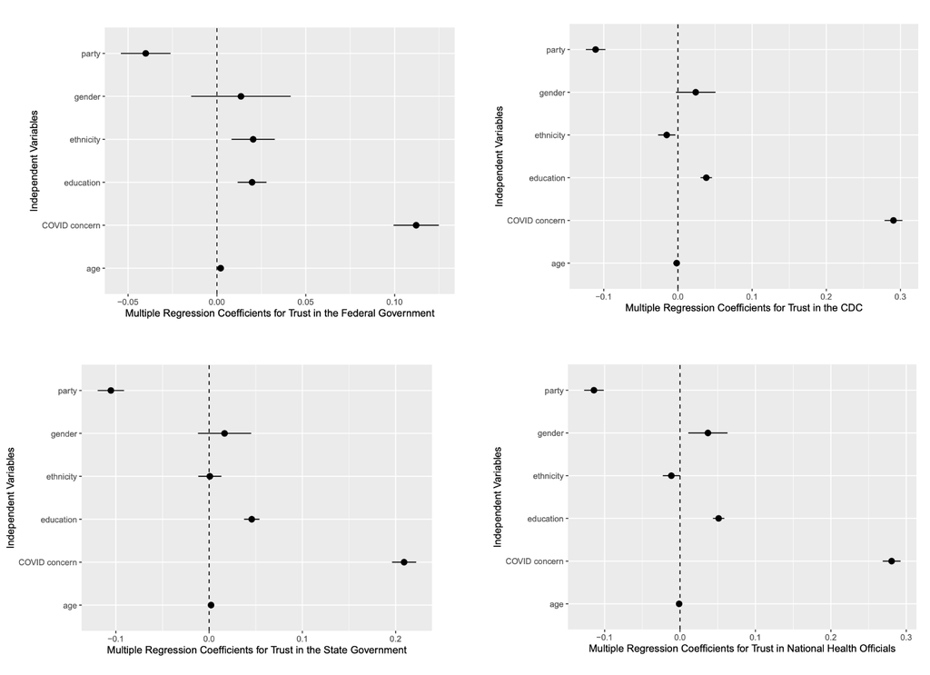

Figure 2:

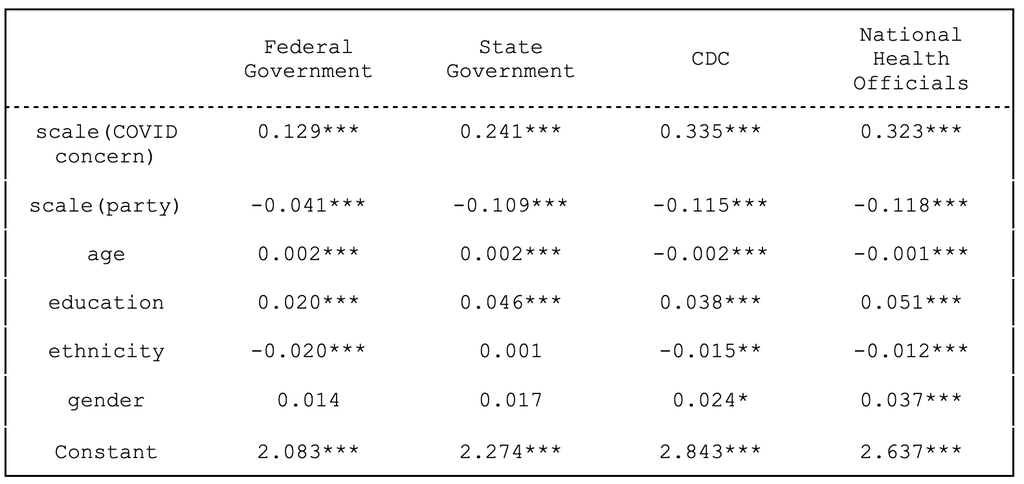

From Figure 2, which presents the scaled regression coefficients of COVID concern and party alongside other control variable coefficients, it is evident that for each trust measure, COVID concern is tied to a larger scaled coefficient than party ID. The larger coefficient of COVID concern indicates that when on the same scale as party identification, COVID concern affects respondent trust in the different expert sources more than party does. Thus, contrary to $H_2$, COVID concern actually has more predictive power than party identification in determining respondent trust across the information sources. This finding was rather intriguing, as it revealed the truth of a balance that seemed could have tipped either way (towards coronavirus concern or partisan identity); the perceived politicization of the COVID-19 pandemic in the United States made it seem plausible that partisanship determined trust in relevant public health officials to an even larger degree than concern about the pandemic itself. Evidently, though partisanship had some effect on trust (as party identification had notably large regression coefficients in relation to the trust outcome variables), it was still trumped by the effect of concern about the pandemic.

Further examining the non-negligible relationship between trust in officials about COVID-19 information and partisanship reveals that different party identification is tied to to different levels of predicted trust in the Centers for Disease Control and Prevention.

Figure 3:

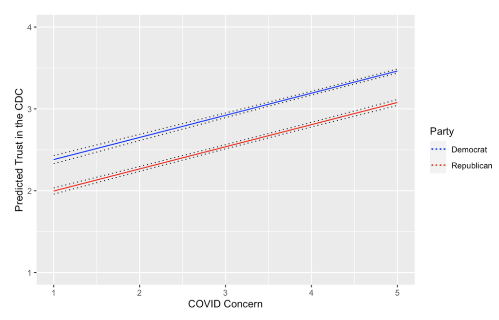

Figure 3 shows the predicted level of trust in the CDC by members of each party as COVID concern rises. Both parties appear to follow the same trend of increased trust in the Centers for Disease Control and Prevention as COVID concern increases in respondents, but CDC trust begins and ends at higher values for Democrats. $H_{2.1}$ stated that “Respondents who identify as Democrats are more likely to trust the CDC than those who identify as Republicans” and was supported, as Democrats are shown to have higher predicted trust in the CDC than Republicans across all values of COVID concern. This result is somewhat expected, as Democrats have been more worried about containing the coronavirus pandemic and open to the advisory of health advisory such as the works that come from the CDC. Additionally, it is expected that Republicans would have less comparative trust in the CDC due to Donald Trump’s attitudes towards the organization: U.S. President from 2016 to late 2020 and popular amongst Republicans, Trump publicly undercut the credibility of the CDC several times, claiming the organization’s vaccine announcements were “just incorrect information,” calling the Director “confused,” and contradicting the advisory messages put out by the CDC.

## Conclusion

In recent years, policymakers and health organizations worldwide have been working to end the coronavirus pandemic that began in late 2019. One of the important factors in this effort is citizen trust in public health information. Thus, this paper aimed to analyze the correlative relationship between the increased concern Americans have felt about the pandemic and their trust in different public bodies of information, including in the federal and state government, Centers for Disease Control and Prevention, and national health advisers. It was hypothesized, and confirmed, that trust was positively correlated with concern across all four measures of trust. Furthermore, it was shown that contrary to the second hypothesis, despite the intense politicization of the COVID-19 pandemic, partisan identity still was not a stronger predictor of trust than actual concern about the pandemic. However, partisanship still had some predictive power for trust in institutions like the CDC, with Democrat respondents being more likely to report higher levels of trust in the CDC than Republicans, confirming the final hypothesis.

These hypotheses were tested using linear regression models and prediction models of data from the Axios/Ipsos Coronavirus Index. This study can be extended and improved upon with randomized controlled methodology, so that the causal, rather than correlative, relationship between pandemic anxiety and trust in important information sources can be uncovered.

This project makes contributions to the growing body of work on the study of the COVID-19 pandemic, American behaviors in crises, the effect of politicization, and the relationship between anxiety and political behavior and attitudes. The pandemic has been handled by many political actors and thus, attitudes related to pandemic policy and information have some political charge, but individual concern about the pandemic in regards to the wellbeing of loved ones and themselves still remains the most significant factor in determining trust in relevant entities – citizen trust, which was previously established to be important emotional capital in areas ranging from pandemic containment to electoral politics, has not been perverted by partisanship yet.

**References**

[1] Albertson, & Gadarian, S. K. (2015). Anxious politics: Democratic Citizenship in a Threatening World. Cambridge University Press.

[2] Albertson, B., & Gadarian, S. K. (2020, March 20). Analysis | This is who Americans trust about coronavirus information. The Washington Post. Retrieved from https://www.washingtonp ost.com/politics/2020/03/20/were-all-anxious-about-pandemic-who-do-americans-want-hear

[3] Blair, R. A., Morse, B. S., & Tsai, L. L. (2017). Public health and public trust: Survey evidence from the Ebola Virus Disease epidemic in Liberia. Social Science & Medicine (1982), 172, 89–97. https://doi.org/10.1016/j.socscimed.2016.11.016

[4] Goodwin, R., Wiwattanapantuwong, J., Tuicomepee, A., Suttiwan, P., & Watakakosol, R. (2020). Anxiety and public responses to covid-19: Early Data from Thailand. Journal of Psychiatric Research, 129, 118–121. https://doi.org/10.1016/j.jpsychires.2020.06.026

[5] Jost, J. T. (2020). A theory of system justification. Harvard University Press.

[6] Marien, & Hooghe, M. (2011). Does political trust matter? An empirical investigation into the relation between political trust and support for law compliance. European Journal of Political Research, 50(2), 267–291. https://doi.org/10.1111/j.1475-6765.2010.01930.x

[7] Mueller, J. E. (1970). Presidential Popularity from Truman to Johnson. The American Political Science Review, 64(1), 18–34. https://doi.org/10.2307/1955610

[8] Noland, M., & Zhang, Y. E. (2021). Covid-19 and the 2020 US presidential election: Did the pandemic cost Donald Trump reelection? SSRN Electronic Journal. https://doi.org/10.2139/ssrn.3807255

[9] Van Bavel, Baicker, K., Boggio, P. S., Capraro, V., Cichocka, A., Cikara, M., Crockett, M. J., Crum, A. J., Douglas, K. M., Druckman, J. N., Drury, J., Dube, O., Ellemers, N., Finkel, E. J., Fowler, J. H., Gelfand, M., Han, S., Haslam, S. A., Jetten, J., … Willer, R. (2020). Using social and behavioural science to support COVID-19 pandemic response. Nature Human Behaviour, 4(5), 460–471. https://doi.org/10.1038/s41562-020-0884-z